# us open

2023-06-13

data from https://www.kaggle.com/datasets/robikscube/pga-tour-golf-data-20152022

with the US open a day away, I’m interested in looking at data from past years to see where gaining strokes compared to the field is the biggest predictor of success. the US open is known for extremely tough roughs, so I was thinking that perhaps this tournament, compared to others, might be predicted by success in certain areas (perhaps around the green or approach) more than putting for example.

```r
dat<- fread("/Users/claire/Documents/Script//ASA All PGA Raw Data - Tourn Level.csv", header=T, data.table=F)


dat$finish2<- ifelse(dat$Finish=="CUT", 999, ifelse(dat$Finish=="DQ" | dat$Finish=="MDF" | dat$Finish=="WD" | dat$Finish=="W/D", NA, dat$Finish))

# that code creates a new variable (finish2) that counts CUT as 999, and anyone we don't care about as NA. now we can get rid of the "T" (stands for a tie) and convert the variable to numeric

dat$finish2<- gsub(pattern = 'T', x = dat$finish2, replacement = '', fixed = T)
dat$finish2<- as.numeric(dat$finish2)

dat$finish_cat<- ifelse(dat$finish2==1, "first", ifelse(dat$finish2==999, "cut", ifelse(dat$finish2>1, "not cut", NA)))

table(dat$finish_cat)
```

```
##
##     cut   first not cut
##   12741     251   17075
```

## US open

```r
# unique(dat$`tournament name`)

us<- dat %>% filter(`tournament name`=="U.S. Open")
table(us$season)
```

```
##
## 2015 2016 2017 2018 2019 2021 2022
##  109  100  116  112  121  262  103
```

```r
head(us)
```

```
##   Player_initial_last tournament id player id hole_par strokes hole_DKP
## 1           A. Hadwin     401353222      5548      280     279     58.0
## 2            A. Noren     401353222      3832      140     146     17.0
## 3           A. Putnam     401353222      5502      280     286     45.5
## 4           A. Schenk     401353222     10372      280     284     53.0
## 5            A. Scott     401353222       388      280     282     54.0
## 6             A. Wise     401353222     10577      280     285     54.0
##   hole_FDP hole_SDP streak_DKP streak_FDP streak_SDP n_rounds made_cut pos
## 1     52.9       60          3        8.6          3        4        1   7
## 2     11.8       22          0        0.0          0        2        0  NA
## 3     37.5       51          0        0.0          0        4        1  31
## 4     42.8       54          0       12.2          0        4        1  24
## 5     46.8       56          0        1.2          0        4        1  14
## 6     43.1       52          0        6.4          0        4        1  27
##   finish_DKP finish_FDP finish_SDP total_DKP total_FDP total_SDP
```

[output cut: 27 more lines]

# look at strokes gained and how they relate to each other and finish

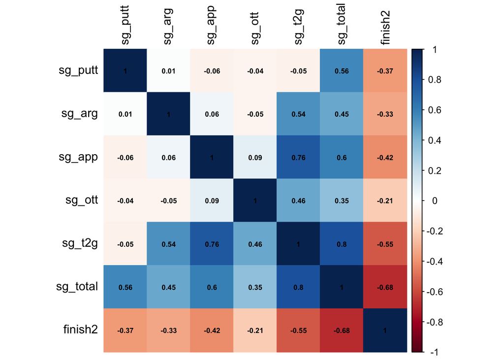

```r
corrs<- us[,c(32:37,38)]
res2 <- rcorr(as.matrix(corrs))


corrs<- res2$r

corrplot(corrs, method = "color",
         type = "full",  number.cex = .6,
         addCoef.col = "black",
         tl.col = "black", tl.srt = 90)
```

the correlation plot above is almost exactly what i would expect. ultimately, strokes gained don’t relate that strongly to each other (*r*s=|0.01-0.09|), with the exception of strokes gained tee to green and total. I’m not 100% sure how strokes gained tee to green and total are calculated, but they definitely are comprised of strokes gained in those other categories (e.g. strokes gained tee to green = strokes gained off the tee, on the approach and around the green). as is such, strokes gained tee to green does *not* correlate strongly with strokes gained putting. this is good as it shows our variables are largely independent of each other! however, it also shows we might be leery of including strokes gained tee to green and strokes gained total in our models, as they might induce multicollinearity. strokes gained total correlates very highly with strokes gained tee to green, *r*=0.80.

otherwise, strokes gained total and tee to green are most strongly associated with finish in the US open (*r*s=-0.55 - -0.68). the other strokes gained categories have correlations ranging from -.21 to -.42 with finish. this means, on average as strokes gained increase, average finish in the US open decreases.

# 1. predict who will make the cut (1/0)

this is a classic classification machine learning problem. we can run logistic regression now, and see *what* predicts making the cut, but we cannot directly score or train a classification model until we have the finishing results from this tournament.

```r
train<- us %>% select(player, `player id`, season, starts_with("sg"), finish_cat)

head(train)
```

```
##            player player id season sg_putt sg_arg sg_app sg_ott sg_t2g sg_total
## 1     Adam Hadwin      5548   2022    1.30   0.80   0.54   0.21   1.54     2.85
## 2 Alexander Noren      3832   2022   -1.42   0.73   0.87  -0.81   0.80    -0.62
## 3   Andrew Putnam      5502   2022    1.43   0.60  -0.48  -0.45  -0.34     1.09
## 4     Adam Schenk     10372   2022    0.66   0.65   0.14   0.14   0.93     1.59
## 5      Adam Scott       388   2022    0.54   0.79   1.20  -0.43   1.55     2.10
## 6      Aaron Wise     10577   2022    0.09   1.08  -0.34   0.53   1.26     1.34
##   finish_cat
## 1    not cut
## 2        cut
## 3    not cut
## 4    not cut
## 5    not cut
## 6    not cut
```

```r
summary(train)
```

```
##     player            player id           season        sg_putt
##  Length:923         Min.   :     16   Min.   :2015   Min.   :-3.5800
##  Class :character   1st Qu.:   1367   1st Qu.:2017   1st Qu.:-0.8800
##  Mode  :character   Median :   4513   Median :2019   Median : 0.0100
##                     Mean   : 178933   Mean   :2019   Mean   :-0.0717
##                     3rd Qu.:   9025   3rd Qu.:2021   3rd Qu.: 0.8000
##                     Max.   :4705886   Max.   :2022   Max.   : 2.8400
##                                                      NA's   :442
##      sg_arg            sg_app            sg_ott            sg_t2g
##  Min.   :-3.7200   Min.   :-3.8100   Min.   :-2.9700   Min.   :-4.7500
##  1st Qu.:-0.4900   1st Qu.:-0.5700   1st Qu.:-0.3600   1st Qu.:-0.9700
##  Median : 0.0300   Median : 0.1200   Median : 0.0400   Median : 0.0300
##  Mean   :-0.0178   Mean   : 0.0274   Mean   : 0.0093   Mean   : 0.0191
##  3rd Qu.: 0.5600   3rd Qu.: 0.7200   3rd Qu.: 0.4200   3rd Qu.: 1.1600
##  Max.   : 2.1200   Max.   : 3.0700   Max.   : 2.0300   Max.   : 4.4800
##  NA's   :442       NA's   :442       NA's   :442       NA's   :442
##     sg_total       finish_cat
##  Min.   :-6.090   Length:923
##  1st Qu.:-1.220   Class :character
##  Median :-0.030   Mode  :character
##  Mean   :-0.051
##  3rd Qu.: 1.280
##  Max.   : 5.570
##  NA's   :442
```

```r
# train %>% filter(is.na(sg_putt)) # if anyone is NA they WD'd or were DQ'd

train<- train %>% filter(!is.na(finish_cat)) # no NAs

train$finish_class<- ifelse(train$finish_cat=="cut", 0, 1)

table(train$finish_cat)
```

```
##
##     cut   first not cut
##     235       4     239
```

```r
table(train$finish_class)
```

```
##
##   0   1
## 235 243
```

```r
train$finish_cat<- NULL
```

### load strokes gained data from 2023 season up through the RBC canadian open

these data I copy and pasted into excel sheets from https://www.pgatour.com/stats/strokes-gained.

```r
names<- c("sg_total", "sg_ott", "sg_putt", "sg_app", "sg_arg", "sg_t2g")

dat<- list()
for (i in names) {
  file<- paste0("/Users/claire/Desktop/",i, ".csv")
  dat[[i]]<- fread(file, header=T, data.table = F)
}

tmp1<- merge(dat[[1]], dat[[2]], by="player")
tmp2<- merge(tmp1, dat[[3]], by="player")
tmp3<- merge(tmp2, dat[[4]], by="player")
tmp4<- merge(tmp3, dat[[5]], by="player")
test<- merge(tmp4, dat[[6]], by="player")

head(test)
```

```
##           player sg_total sg_ott sg_putt sg_app sg_arg sg_t2g
## 1 Aaron Baddeley    0.404 -0.423   0.351  0.025  0.534  0.053
## 2      Aaron Rai    0.491  0.265  -0.391  0.390  0.136  0.882
## 3     Aaron Wise   -0.138 -0.170   0.559 -0.795  0.228 -0.696
## 4    Adam Hadwin    0.825  0.048   0.356  0.350  0.103  0.469
## 5      Adam Long   -0.264 -0.285   0.406 -0.539  0.094 -0.670
## 6    Adam Schenk    0.625  0.024   0.355  0.099  0.106  0.271
```

```r
nrow(test)
```

```
## [1] 198
```

```r
rm(tmp1,tmp2,tmp3,tmp4)
```

now we have training data from 2019-2022 and testing data that is only strokes gained in 2023 thus far.

```r
head(test)
```

```
##           player sg_total sg_ott sg_putt sg_app sg_arg sg_t2g
## 1 Aaron Baddeley    0.404 -0.423   0.351  0.025  0.534  0.053
## 2      Aaron Rai    0.491  0.265  -0.391  0.390  0.136  0.882
## 3     Aaron Wise   -0.138 -0.170   0.559 -0.795  0.228 -0.696
## 4    Adam Hadwin    0.825  0.048   0.356  0.350  0.103  0.469
## 5      Adam Long   -0.264 -0.285   0.406 -0.539  0.094 -0.670
## 6    Adam Schenk    0.625  0.024   0.355  0.099  0.106  0.271
```

```r
head(train)
```

```
##            player player id season sg_putt sg_arg sg_app sg_ott sg_t2g sg_total
## 1     Adam Hadwin      5548   2022    1.30   0.80   0.54   0.21   1.54     2.85
## 2 Alexander Noren      3832   2022   -1.42   0.73   0.87  -0.81   0.80    -0.62
## 3   Andrew Putnam      5502   2022    1.43   0.60  -0.48  -0.45  -0.34     1.09
## 4     Adam Schenk     10372   2022    0.66   0.65   0.14   0.14   0.93     1.59
## 5      Adam Scott       388   2022    0.54   0.79   1.20  -0.43   1.55     2.10
## 6      Aaron Wise     10577   2022    0.09   1.08  -0.34   0.53   1.26     1.34
##   finish_class
## 1            1
## 2            0
## 3            1
## 4            1
## 5            1
## 6            1
```

```r
test$season<- 2023

test<- test %>% select(colnames(train)[c(1,3:9)])

head(train)
```

```
##            player player id season sg_putt sg_arg sg_app sg_ott sg_t2g sg_total
## 1     Adam Hadwin      5548   2022    1.30   0.80   0.54   0.21   1.54     2.85
## 2 Alexander Noren      3832   2022   -1.42   0.73   0.87  -0.81   0.80    -0.62
## 3   Andrew Putnam      5502   2022    1.43   0.60  -0.48  -0.45  -0.34     1.09
## 4     Adam Schenk     10372   2022    0.66   0.65   0.14   0.14   0.93     1.59
## 5      Adam Scott       388   2022    0.54   0.79   1.20  -0.43   1.55     2.10
## 6      Aaron Wise     10577   2022    0.09   1.08  -0.34   0.53   1.26     1.34
##   finish_class
## 1            1
## 2            0
## 3            1
## 4            1
## 5            1
## 6            1
```

```r
head(test)
```

```
##           player season sg_putt sg_arg sg_app sg_ott sg_t2g sg_total
## 1 Aaron Baddeley   2023   0.351  0.534  0.025 -0.423  0.053    0.404
## 2      Aaron Rai   2023  -0.391  0.136  0.390  0.265  0.882    0.491
## 3     Aaron Wise   2023   0.559  0.228 -0.795 -0.170 -0.696   -0.138
## 4    Adam Hadwin   2023   0.356  0.103  0.350  0.048  0.469    0.825
## 5      Adam Long   2023   0.406  0.094 -0.539 -0.285 -0.670   -0.264
## 6    Adam Schenk   2023   0.355  0.106  0.099  0.024  0.271    0.625
```

```r
sum(test$player %in% train$player) # 121 in the testing set are in the training set
```

```
## [1] 121
```

### in the training data what predicts making the cut or not?

here, we let strokes gained predict whether someone made the cut or not, and included random intercepts and slopes for both player and season. this allows each strokes gained category to have it’s own intercept (or starting point) per season **and** per player but still draws from the same joint distribution. allowing random intercepts means each season strokes gained in a certain area may be higher or lower than in other seasons. just the same, some players might be gaining more strokes in certain areas than others due to specific skill sets or injuries, so it is important to allow random intercepts for players when they are measured more than once. allowing random intercepts helps account for non-independence of observations induced by occurances of multiple players and years.

it also allows each strokes gained category to have it’s own slope (or effect on making the cut) per season because the course, as well as each player, changes year to year, and some courses might have tighter fairways or harder greens, worse weather etc.

```r
mod<- glm(finish_class~sg_ott+sg_app+sg_putt+sg_t2g+sg_arg + (season|season) + (1|`player id`), data=train)
summary(mod)
```

```
##
## Call:
## glm(formula = finish_class ~ sg_ott + sg_app + sg_putt + sg_t2g +
##     sg_arg + (season | season) + (1 | `player id`), data = train)
##
## Deviance Residuals:
##      Min        1Q    Median        3Q       Max
## -0.64916  -0.32210   0.02423   0.29593   0.87129
##
## Coefficients: (2 not defined because of singularities)
##                     Estimate Std. Error t value Pr(>|t|)
## (Intercept)          0.51829    0.01706  30.374   <2e-16 ***
## sg_ott               5.71459    2.59785   2.200   0.0283 *
## sg_app               5.73966    2.59702   2.210   0.0276 *
## sg_putt              0.16912    0.01498  11.292   <2e-16 ***
## sg_t2g              -5.55827    2.59743  -2.140   0.0329 *
## sg_arg               5.74931    2.59791   2.213   0.0274 *
## season | seasonTRUE       NA         NA      NA       NA
## 1 | `player id`TRUE       NA         NA      NA       NA
## ---
## Signif. codes:  0 '***' 0.001 '**' 0.01 '*' 0.05 '.' 0.1 ' ' 1
##
## (Dispersion parameter for gaussian family taken to be 0.1383402)
##
##     Null deviance: 119.467  on 477  degrees of freedom
## Residual deviance:  65.297  on 472  degrees of freedom
## AIC: 418.96
##
## Number of Fisher Scoring iterations: 2
```

```r
exp(coef(mod))
```

```
##         (Intercept)              sg_ott              sg_app             sg_putt
##        1.679149e+00        3.032601e+02        3.109586e+02        1.184267e+00
##              sg_t2g              sg_arg season | seasonTRUE 1 | `player id`TRUE
##        3.855443e-03        3.139753e+02                  NA                  NA
```

```r
mod<- glm(finish_class~sg_ott+sg_app+sg_putt+sg_arg + (season|season) + (1|`player id`), data=train)
summary(mod)
```

```
##
## Call:
## glm(formula = finish_class ~ sg_ott + sg_app + sg_putt + sg_arg +
##     (season | season) + (1 | `player id`), data = train)
##
## Deviance Residuals:
##      Min        1Q    Median        3Q       Max
## -0.63557  -0.32433   0.02811   0.30099   0.92712
##
## Coefficients: (2 not defined because of singularities)
##                     Estimate Std. Error t value Pr(>|t|)
## (Intercept)          0.51745    0.01712  30.219  < 2e-16 ***
## sg_ott               0.15571    0.02638   5.902 6.87e-09 ***
## sg_app               0.18236    0.01579  11.550  < 2e-16 ***
## sg_putt              0.17086    0.01501  11.382  < 2e-16 ***
## sg_arg               0.19021    0.02110   9.014  < 2e-16 ***
## season | seasonTRUE       NA         NA      NA       NA
## 1 | `player id`TRUE       NA         NA      NA       NA
## ---
## Signif. codes:  0 '***' 0.001 '**' 0.01 '*' 0.05 '.' 0.1 ' ' 1
##
## (Dispersion parameter for gaussian family taken to be 0.1393871)
##
##     Null deviance: 119.47  on 477  degrees of freedom
## Residual deviance:  65.93  on 473  degrees of freedom
## AIC: 421.58
##
## Number of Fisher Scoring iterations: 2
```

```r
exp(coef(mod))
```

```
##         (Intercept)              sg_ott              sg_app             sg_putt
##            1.677751            1.168486            1.200052            1.186329
##              sg_arg season | seasonTRUE 1 | `player id`TRUE
##            1.209507                  NA                  NA
```

if we remove strokes gained tee to green, the odds ratios make a bit more sense, and are all in the direction that we would expect: gaining strokes in every area increases your chances of making the cut significantly.

# 2. predict overall finish

here, we can run simple linear regression models to predict each person’s finish based on strokes gained.

```r
linear<- us %>% select(player, `player id`, season, starts_with("sg"), finish2) %>%
  filter(!is.na(finish2))

head(linear)
```

```
##            player player id season sg_putt sg_arg sg_app sg_ott sg_t2g sg_total
## 1     Adam Hadwin      5548   2022    1.30   0.80   0.54   0.21   1.54     2.85
## 2 Alexander Noren      3832   2022   -1.42   0.73   0.87  -0.81   0.80    -0.62
## 3   Andrew Putnam      5502   2022    1.43   0.60  -0.48  -0.45  -0.34     1.09
## 4     Adam Schenk     10372   2022    0.66   0.65   0.14   0.14   0.93     1.59
## 5      Adam Scott       388   2022    0.54   0.79   1.20  -0.43   1.55     2.10
## 6      Aaron Wise     10577   2022    0.09   1.08  -0.34   0.53   1.26     1.34
##   finish2
## 1       7
## 2     999
## 3      31
## 4      24
## 5      14
## 6      27
```

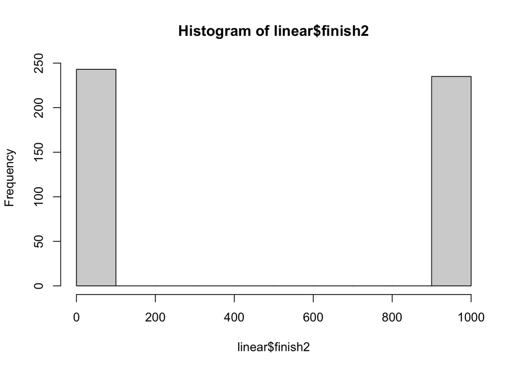

```r
hist(linear$finish2)
```

```r
linear$finish2<- ifelse(linear$finish2==999, 78, linear$finish2)

mod<- lmer(finish2~sg_ott+sg_app+sg_putt+sg_t2g+sg_arg +(season|season) + (1|`player id`), data=linear)
```

```
## boundary (singular) fit: see help('isSingular')
```

```r
summary(mod)
```

```
## Linear mixed model fit by REML ['lmerMod']
## Formula: finish2 ~ sg_ott + sg_app + sg_putt + sg_t2g + sg_arg + (season |
##     season) + (1 | `player id`)
##    Data: linear
##
## REML criterion at convergence: 3939
##
## Scaled residuals:
##     Min      1Q  Median      3Q     Max
## -3.1196 -0.7250 -0.2138  0.7812  2.0883
##
## Random effects:
##  Groups    Name        Variance Std.Dev. Corr
##  player id (Intercept)   1.8660  1.3660
##  season    (Intercept)   0.0000  0.0000
##            season2021    0.1682  0.4101    NaN
##            season2022   40.0114  6.3255    NaN -0.80
##  Residual              230.0580 15.1677
## Number of obs: 478, groups:  player id, 245; season, 3
##
## Fixed effects:
##              Estimate Std. Error t value
## (Intercept)   52.4833     0.8305  63.198
## sg_ott      -298.5576   107.2274  -2.784
## sg_app      -298.3450   107.1924  -2.783
## sg_putt      -11.5875     0.6154 -18.828
## sg_t2g       286.2186   107.2042   2.670
## sg_arg      -298.3895   107.2276  -2.783
##
## Correlation of Fixed Effects:
##         (Intr) sg_ott sg_app sg_ptt sg_t2g
## sg_ott   0.070
## sg_app   0.070  1.000
## sg_putt  0.084 -0.042 -0.042
## sg_t2g  -0.070 -1.000 -1.000  0.043
## sg_arg   0.070  1.000  1.000 -0.043 -1.000
## optimizer (nloptwrap) convergence code: 0 (OK)
## boundary (singular) fit: see help('isSingular')
```

```r
mod<- lmer(finish2~sg_putt+sg_t2g +(season|season) + (1|`player id`), data=linear)
```

```
## boundary (singular) fit: see help('isSingular')
```

```r
summary(mod)
```

```
## Linear mixed model fit by REML ['lmerMod']
## Formula: finish2 ~ sg_putt + sg_t2g + (season | season) + (1 | `player id`)
##    Data: linear
##
## REML criterion at convergence: 3962.1
##
## Scaled residuals:
##     Min      1Q  Median      3Q     Max
## -3.1152 -0.7498 -0.2153  0.7732  2.0530
##
## Random effects:
##  Groups    Name        Variance  Std.Dev.  Corr
##  player id (Intercept) 1.594e+00 1.262e+00
##  season    (Intercept) 5.233e-08 2.288e-04
##            season2021  1.337e-07 3.656e-04 -1.00
##            season2022  3.243e+01 5.695e+00 -0.83  0.83
##  Residual              2.328e+02 1.526e+01
## Number of obs: 478, groups:  player id, 245; season, 3
##
## Fixed effects:
##             Estimate Std. Error t value
## (Intercept)  52.6072     0.7861   66.92
## sg_putt     -11.6545     0.6173  -18.88
## sg_t2g      -12.1671     0.4502  -27.03
##
## Correlation of Fixed Effects:
##         (Intr) sg_ptt
## sg_putt 0.095
## sg_t2g  0.025  0.055
## optimizer (nloptwrap) convergence code: 0 (OK)
## boundary (singular) fit: see help('isSingular')
```

interestingly, if we just look at strokes gained tee to green and putting, they both drastically decrease one’s expected finish with every additional stroke gained. that is the direction we would expect. I would guess perhaps there is some sort of suppression effect occurring when strokes gained tee to green is in the model with all other variables that comprise strokes gained tee to green. it might make sense thus to take it out of the machine learning model to follow.

```r
mod<- lmer(finish2~sg_ott+sg_app+sg_putt+sg_arg +(season|season) + (1|`player id`), data=linear)
```

```
## boundary (singular) fit: see help('isSingular')
```

```r
summary(mod)
```

```
## Linear mixed model fit by REML ['lmerMod']
## Formula: finish2 ~ sg_ott + sg_app + sg_putt + sg_arg + (season | season) +
##     (1 | `player id`)
##    Data: linear
##
## REML criterion at convergence: 3957.2
##
## Scaled residuals:
##     Min      1Q  Median      3Q     Max
## -3.1233 -0.7478 -0.2205  0.7683  2.0504
##
## Random effects:
##  Groups    Name        Variance  Std.Dev.  Corr
##  player id (Intercept) 1.691e+00 1.300e+00
##  season    (Intercept) 8.567e-08 2.927e-04
##            season2021  1.452e-08 1.205e-04 -1.00
##            season2022  3.278e+01 5.725e+00 -0.99  0.99
##  Residual              2.333e+02 1.528e+01
## Number of obs: 478, groups:  player id, 245; season, 3
##
## Fixed effects:
##             Estimate Std. Error t value
## (Intercept)  52.6012     0.7877   66.78
## sg_ott      -12.2875     1.0860  -11.31
## sg_app      -12.1614     0.6498  -18.71
## sg_putt     -11.6544     0.6189  -18.83
## sg_arg      -12.1148     0.8668  -13.98
##
## Correlation of Fixed Effects:
##         (Intr) sg_ott sg_app sg_ptt
## sg_ott   0.002
## sg_app   0.009 -0.087
## sg_putt  0.094  0.034  0.060
## sg_arg   0.033  0.056 -0.060 -0.012
## optimizer (nloptwrap) convergence code: 0 (OK)
## boundary (singular) fit: see help('isSingular')
```

finally, removing tee to green from the original model we get much more realistic results. every additional stroke gained in every area (off the tee, on the approach, around the green and putting) all decrease one’s expected finish by about 11 to 12.

```r
set.seed(2)

preProcess <- c("center","scale")
trControl <- trainControl(method = "repeatedcv",number = 10,repeats = 10)

model <- train(finish2~sg_putt+sg_arg+sg_app+sg_ott, data=linear, preProcess = preProcess, trControl=trControl) ### run the model


test$finish_pred <- predict(model, test)

head(test)
```

```
##           player season sg_putt sg_arg sg_app sg_ott sg_t2g sg_total
## 1 Aaron Baddeley   2023   0.351  0.534  0.025 -0.423  0.053    0.404
## 2      Aaron Rai   2023  -0.391  0.136  0.390  0.265  0.882    0.491
## 3     Aaron Wise   2023   0.559  0.228 -0.795 -0.170 -0.696   -0.138
## 4    Adam Hadwin   2023   0.356  0.103  0.350  0.048  0.469    0.825
## 5      Adam Long   2023   0.406  0.094 -0.539 -0.285 -0.670   -0.264
## 6    Adam Schenk   2023   0.355  0.106  0.099  0.024  0.271    0.625
##   finish_pred
## 1    48.94883
## 2    49.30457
## 3    70.06233
## 4    36.80317
## 5    62.19587
## 6    47.03707
```

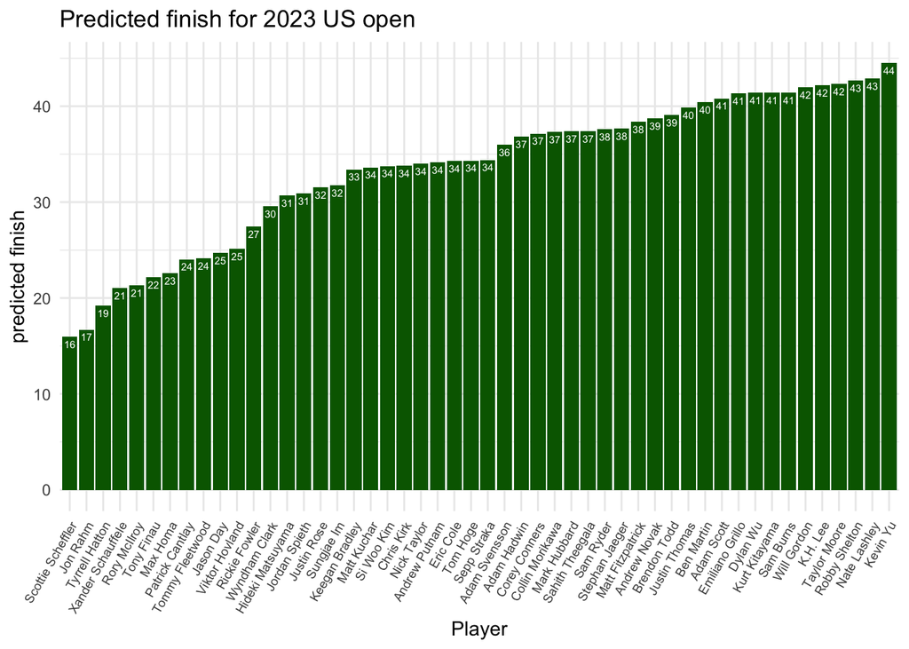

```r
plot<- test %>% arrange(finish_pred)

plot<- plot[1:50,]

ggplot(plot, aes(x = reorder(player, finish_pred), y=finish_pred))+
  geom_bar(stat="identity", fill="darkgreen")+
  labs(title="Predicted finish for 2023 US open",x="Player", y = "predicted finish")+
  theme_minimal()+
  geom_text(
    aes(label = round(finish_pred,0)),
    colour = "white", size = 2,
    vjust = 1.5, position = position_dodge(.9)) +
  theme(legend.position = "bottom", axis.text.x = element_text(angle=60, size=7, hjust = 1))
```

a simple linear prediction model here suggests Scottie will finish the lowest, followed by Jon Rahm, Tyrell Hatton, Xander, Rory and Tony Finau. not too bad if you ask me, although the lowest it is predicting someone to go is 16, so maybe not entirely precise. those guys are definitely mostly playing really well right now though!

```r
linear<- us %>% select(player, `player id`, season, starts_with("sg"), finish2) %>%
  filter(!is.na(finish2)) %>%
  filter(finish2<900)

head(linear)
```

```
##          player player id season sg_putt sg_arg sg_app sg_ott sg_t2g sg_total
## 1   Adam Hadwin      5548   2022    1.30   0.80   0.54   0.21   1.54     2.85
## 2 Andrew Putnam      5502   2022    1.43   0.60  -0.48  -0.45  -0.34     1.09
## 3   Adam Schenk     10372   2022    0.66   0.65   0.14   0.14   0.93     1.59
## 4    Adam Scott       388   2022    0.54   0.79   1.20  -0.43   1.55     2.10
## 5    Aaron Wise     10577   2022    0.09   1.08  -0.34   0.53   1.26     1.34
## 6  Brian Harman      1225   2022    0.58  -0.63   0.37   0.28   0.01     0.59
##   finish2
## 1       7
## 2      31
## 3      24
## 4      14
## 5      27
## 6      43
```

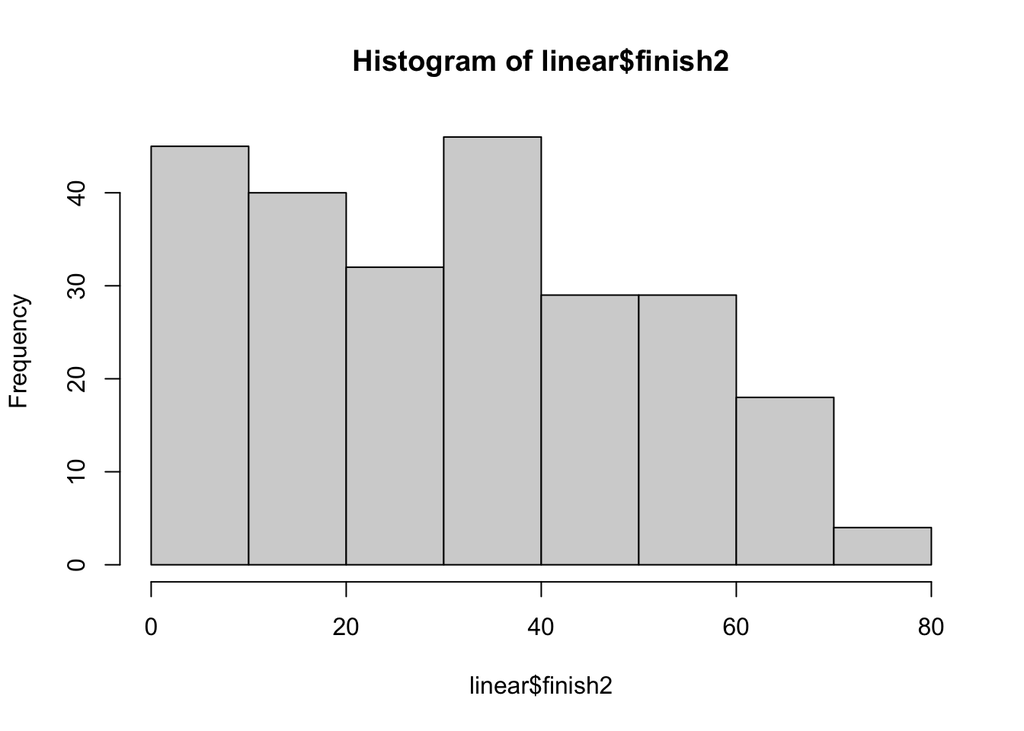

```r
hist(linear$finish2)
```

```r
table(linear$finish2)
```

```
##
##  1  2  3  4  5  6  7  8  9 10 12 13 14 15 16 17 19 21 22 23 24 26 27 28 30 31
##  4  5  6  5  2  2 11  5  3  2  6  6  7  4  5  5  7  7  1  8  3  5  3  4  1 10
## 32 34 35 37 38 40 43 46 47 48 49 50 51 52 53 54 55 56 57 58 59 61 62 63 64 65
##  3  4 12  6  5  6 12  3  2  1  7  4  3  6  1  1  4  3  4  5  2  2  2  1  1  8
## 68 70 72 76 77
##  2  2  2  1  1
```

```r
mod<- lmer(finish2~sg_ott+sg_app+sg_putt+sg_arg +(1|`player id`), data=linear)
```

```
## boundary (singular) fit: see help('isSingular')
```

```r
summary(mod)
```

```
## Linear mixed model fit by REML ['lmerMod']
## Formula: finish2 ~ sg_ott + sg_app + sg_putt + sg_arg + (1 | `player id`)
##    Data: linear
##
## REML criterion at convergence: 1529.6
##
## Scaled residuals:
##     Min      1Q  Median      3Q     Max
## -3.0208 -0.6297 -0.1544  0.5621  5.3308
##
## Random effects:
##  Groups    Name        Variance Std.Dev.
##  player id (Intercept)  0.00    0.000
##  Residual              32.66    5.715
## Number of obs: 243, groups:  player id, 146
##
## Fixed effects:
##             Estimate Std. Error t value
## (Intercept)  48.2335     0.4932   97.80
## sg_ott      -13.1841     0.7036  -18.74
## sg_app      -14.2677     0.4637  -30.77
## sg_putt     -14.4425     0.4197  -34.41
## sg_arg      -13.9635     0.6140  -22.74
##
## Correlation of Fixed Effects:
##         (Intr) sg_ott sg_app sg_ptt
## sg_ott  -0.153
## sg_app  -0.455 -0.185
## sg_putt -0.397  0.079  0.167
## sg_arg  -0.339  0.014  0.021  0.081
## optimizer (nloptwrap) convergence code: 0 (OK)
## boundary (singular) fit: see help('isSingular')
```

the results are about the same, but each additional stroke gained is reducing one’s expected finish a bit more, as expected as these are only the players who performed well enough to make the cut.

```r
sgt<- ggplot(linear, aes(x=sg_total, y=finish2, color=finish2)) +
  geom_point() +
  facet_wrap(~season)+
  ylab("Finish") +
  xlab("Strokes gained total")+
  geom_hline(yintercept = 10, color="red")+
  scale_colour_gradientn(colours = terrain.colors(10))

sgt2g<- ggplot(linear, aes(x=sg_t2g, y=finish2, color=finish2)) +
  geom_point() +
  facet_wrap(~season)+
  ylab("Finish") +
  xlab("Strokes gained tee to green")+
  geom_hline(yintercept = 10, color="red")+
  scale_colour_gradientn(colours = terrain.colors(10))

sgott<- ggplot(linear, aes(x=sg_ott, y=finish2, color=finish2)) +
  geom_point() +
  facet_wrap(~season)+
  ylab("Finish") +
  xlab("Strokes gained off the tee")+
  geom_hline(yintercept = 10, color="red")+
  scale_colour_gradientn(colours = terrain.colors(10))

sgapp<- ggplot(linear, aes(x=sg_app, y=finish2, color=finish2)) +
  geom_point() +
  facet_wrap(~season)+
  ylab("Finish") +
  xlab("Strokes gained on the approach")+
  geom_hline(yintercept = 10, color="red")+
  scale_colour_gradientn(colours = terrain.colors(10))

sgarg<- ggplot(linear, aes(x=sg_arg, y=finish2, color=finish2)) +
  geom_point() +
  facet_wrap(~season)+
  ylab("Finish") +
  xlab("Strokes gained around the green")+
  geom_hline(yintercept = 10, color="red")+
  scale_colour_gradientn(colours = terrain.colors(10))

sgp<- ggplot(linear, aes(x=sg_putt, y=finish2, color=finish2)) +
  geom_point() +
  facet_wrap(~season)+
  ylab("Finish") +
  xlab("Strokes gained putting")+
  geom_hline(yintercept = 10, color="red")+
  scale_colour_gradientn(colours = terrain.colors(10))
```

the below plot shows all strokes gained categories and their relationships with finish over the last 3 years looked at in this analysis. strokes gained total has the clearest association with finish, which makes sense (green = lower finish = better). the red line represents a top 10 finish at a US open. for the most part, people finishing in the top 10 are also in the positive in strokes gained categories (but not always!)

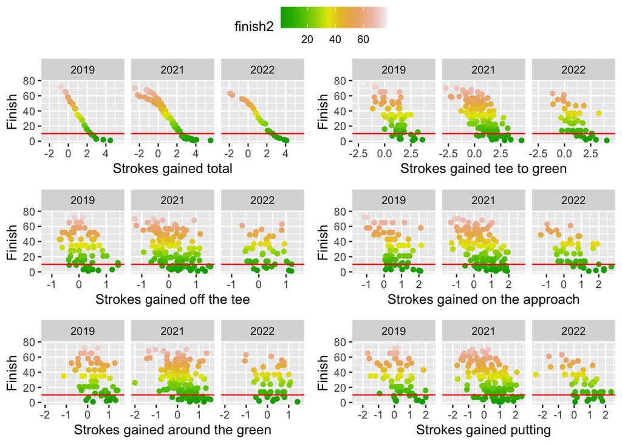

```r
ggarrange(sgt, sgt2g, sgott, sgapp, sgarg, sgp, nrow=3, ncol=2, common.legend = T)
```